# 3 STEPS pipeline for Identification & Visualization of Significant Methylation Susceptible Loci (MSL)

Lakshay Anand

2/15/2019

## CONTENTS

What the pipeline does?

What you need?

Getting Started

Function Sourcecode

## What do you need?

You will need to install the package `msap` and prepare the **data format** that it needs. That is all you need for this pipeline.

## Getting Started

Lets run the three steps for the pipeline. Before starting with the following command, copy and run the function sourcecode provided in the last section.

### STEP 1

Use the `msap` package and the input data to find the MSL.

```r
library(msap)
msap.out=msap("your_data.csv",name = "any_name")
```

### STEP 2

pass the output to the custom function `find.sig.loci( )` (more info about the function in subsequent sections)

```r
my.out=find.sig.loci(msap.out)
```

```
## analysing....
## Total loci: 153
## Total samples: 41
## Total number of groups: 2
```

```
## replacing types with numbers suitable for fisher test and heatmap..
```

```
## Performing multiple fisher tests
```

```
## Calculating FDR using benjamini and hochberg
```

[output not shown]

```
## filtering significant loci
```

```
## 25  loci are found significant.
```

Note: The warning during coercion to NA is produced when the input data has only one variable and can’t be used for fisher test. The cistome function returns a na for such cases.

and now the output `my.out` is a list of five elements:

```r
names(my.out)
```

```
## [1] "heatmap.matrix"   "Significant.Loci" "All.loci.results"
## [4] "complete.data"    "group.cont"
```

where, *`heatmap.matrix` is a output matrix of numbers significant loci suitable for creating the heatmap.

*`significant.loci` is character vector containing the significant loci selected.

*`All.loci.results` is the overall result showing the p-values and adjusted p-values for all the loci(not filtered). The pipeline uses a filter of FDR<0.05. While using this data you can use your own filter.

*`complete.data` contains the matrix of all loci and samples together.

*`group.count` can be used to know the sample count for each group for using it in heatmap cluster coloring.

```r
#significant loci
my.out$Significant.Loci
```

```
##  [1] "X104.372303"  "X166.2043885" "X177.2979221" "X178.4825882"
##  [5] "X189.2535821" "X247.2600556" "X264.6262937" "X306.2137821"
##  [9] "X307.6917062" "X312.9926866" "X329.91875"   "X347.8885"
## [13] "X365.7359649" "X373.8959322" "X375.1234703" "X376.7047115"
## [17] "X380.05265"   "X384.7438168" "X394.4164319" "X439.0106726"
## [21] "X447.656391"  "X450.4504651" "X456.8275"    "X526.8863354"
## [25] "X547.6297468"
## attr(,"na.action")
## [1] 20
## attr(,"class")
## [1] "omit"
```

```r
head(my.out$All.loci.results)
```

[output not shown]

```r
#number of samples
my.out$group.cont
```

```
##   grpNAME grpCOUNT
## 1      G1       21
## 2      G2       20
```

### STEP3

Now get the heatmap matrix data and plot the heatmap. I have used the `heatmap.2( )` function from `gplots` package. You can use any package or settings.

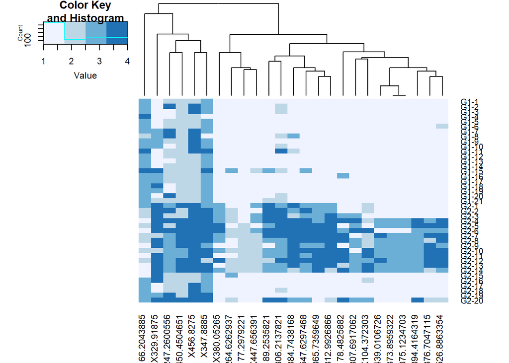

```r
library(gplots)
heat.data=my.out$heatmap.matrix

#for getting the group colors for the samples marked as G1,G2.. size of which obtained from group,cont dataframe
row.cluster.colors= c(rep("green",21),rep("red",20))
heatmap.2(as.matrix(heat.data),
                        Rowv = F,
                        trace = "none",
                        col = c('#eff3ff','#bdd7e7','#6baed6','#2171b5') ,
                        RowSideColors = ,
                        dendrogram="column")
```

and its done!

## Function Sourcecode

Copy the following function code and run it in your R environment. This will create two functions, `find.sig.loci( )` and `tryCatchFisher( )`.

```r
###########################################################################
########### STATISTICAL ANALYSIS FOR FINDING SIGNIFICANT LOCI BW GROUPS####
############## @author: Lakshay Anand #####################################


find.sig.loci<- function(msap.input){

  out=list()

  ptrn=msap.input[[2]]
  grpNAME=c()
  grpCOUNT=c()
  grpALL=data.frame()
  for(d in 1:length(ptrn)){

    Grp=ptrn[[d]]
    rownames(Grp)= c(paste("G",d,"-",c(1:nrow(Grp)),sep = ""))
    grpNAME[d]=paste("G",d,sep = "")
    grpCOUNT[d]=nrow(Grp)
    grpALL=rbind.data.frame(grpALL,Grp)

  }


  cat("analysing.... \n")
  cat("Total loci:",ncol(grpALL),"\n")
  cat("Total samples:",nrow(grpALL),"\n")
  cat("Total number of groups:",length(ptrn),"\n")


  ############## replace types with numbers
  message("replacing types with numbers suitable for fisher test and heatmap.. \n")
  for(i in 1:ncol(grpALL)){


    for(j in 1:nrow(grpALL)){

      if(grpALL[j,i]=="u"){

        grpALL[j,i]=1
      }
      else if(grpALL[j,i]=="h"){

        grpALL[j,i]=2
      } else if(grpALL[j,i]=="i"){

        grpALL[j,i]=3
      } else if(grpALL[j,i]=="f"){

        grpALL[j,i]=4
      }



    }



  }

  for(i in 1:ncol(grpALL)){

    grpALL[,i]=as.integer(grpALL[,i])

  }



  #####################################################
  #creating groups vector for fisher test
  groups.vector=c()

  for(i in 1:length(rownames(grpALL))){

    groups.vector[i]=strsplit(rownames(grpALL)[i],"-")[[1]][1]
  }


  ############### multiple fisher test ##########
  message("Performing multiple fisher tests \n")
  pval=c()
  loci=c()
  for(i in 1:ncol(grpALL)){

    loci[i]=colnames(grpALL)[i]

    pval[i]=tryCatchFisher(table(groups.vector,grpALL[,i]))


  }


  message("Calculating FDR using benjamini and hochberg \n")
  #result of the fisher test wit p-vale adjustment using benjamini

  grpALL_LOCI=data.frame(loci,pval,p.adjust(pval,method = "BH"))

  message("filtering significant loci \n")
  ### filter the loci with FDR <0.05
  grp_sigloci=grpALL_LOCI[grpALL_LOCI[,3]<0.05,]



  ###collect the significant loci
  sig.loci=as.character(grp_sigloci[,1])
  sig.loci=na.omit(sig.loci)
  cat(length(sig.loci)," loci are found significant. \n")
  ##### filter the loci from the matrix

  grpALL_with_sig_loci=grpALL[,sig.loci]


  out[[1]]=as.matrix(grpALL_with_sig_loci)
  out[[2]]=sig.loci
  out[[3]]=grpALL_LOCI
  out[[4]]=grpALL
  out[[5]]=data.frame(grpNAME,grpCOUNT)
  names(out)=c("heatmap.matrix","Significant.Loci","All.loci.results","complete.data","group.cont")

  return(out)
  }




#### the fisher test in try catch
tryCatchFisher<-function(v){
  tryCatch(fisher.test(v)[[1]],
           error = function(e) {"na"})
}
```